# final project

# Places

I need to see how often each place is mentioned in the dialogue.

## Where every place mentioned is found? (bar chart)

Diagon Alley, Dwellings, Hogsmeade, Hogwarts, Other Magic Locations

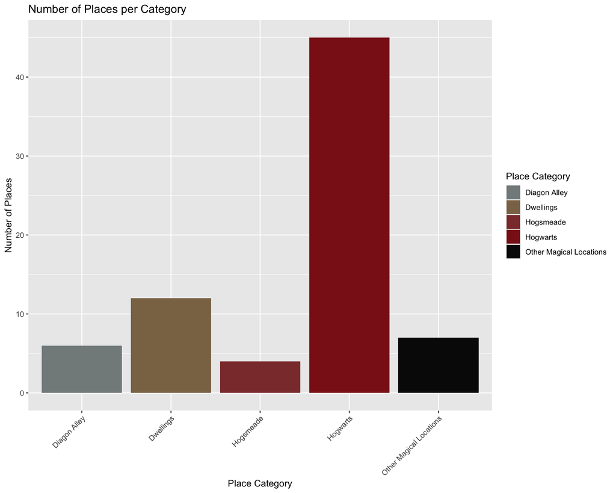

# Spells

## What category do these spells fall into?

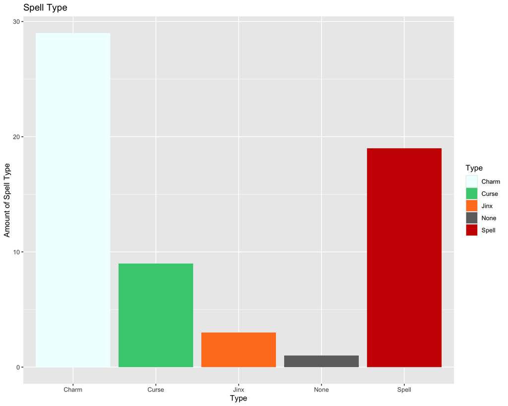

- charm: a spell that adds properties to an object or person without changing its fundamental nature
- jinx: a minor type of dark magic that causes inconvenience or mild harm to the target
- spell: a command that uses a specific incantation and wand movement to produce a magical effect
- curse: a command that uses a specific incantation and wand movement to produce a magical effect

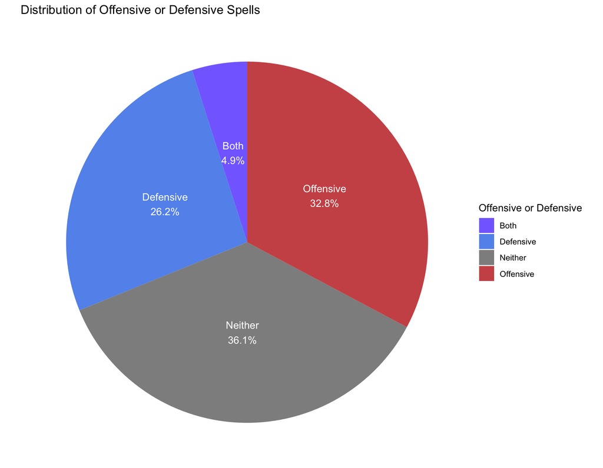

- offensive: are used to attack or harm an opponent - defensive: are used to protect against attacks

## Does the color of the light emmitted from the spell that was cast correlate with which type of spell it is?

```r
spell_name <- spells$`Spell Name`
spell_incantation <- spells$Incantation
spell_type <- spells$Type
spell_light <- spells$Light
kable(cbind(spell_incantation, spell_type, spell_light), "html") %>%
    kable_styling() %>%
    scroll_box(width = "1000px", height = "500px")
```

| spell_incantation | spell_type | spell_light |
| --- | --- | --- |
| Accio | Charm | NA |
| Aguamenti | Charm | Icy blue |
| Alarte Ascendare | Spell | Red |
| Alohomora | Charm | Blue |
| Arania Exumai | Spell | Blue |
| Arresto Momentum | Charm | NA |
| Avada Kedavra | Curse | Green |
| Bombarda | Charm | NA |
| Brackium Emendo | Spell | Blue |
| Cistem Aperio | Spell | White |
| Colloportus | Charm | NA |
| Confringo | Curse | Fiery Orange |
| Crucio | Curse | Red |
| Diffindo | Charm | Light green |
| Dissendium | Charm | NA |
| Engorgio | Charm | Icy blue |
| Episkey | Spell | NA |
| Expecto Patronum | Charm | Silver |
| Expelliarmus | Curse | Scarlet |
| Expulso | Curse | Blue |
| Finite | Spell | Red |
| Homenum Revelio | Spell | NA |
| Immobulus | Charm | Blue |
| Impedimenta | Jinx | Turquoise |
| Imperio | Curse | NA |
| Incarcerous | Spell | NA |
| Incendio | Charm | Orange |
| Levicorpus | Spell | Green |
| Locomotor | Charm | NA |
| Locomotor Mortis | Curse | Purple |
| Lumos | Charm | White |
| Lumos Maxima | Spell | White |
| Lumos Solem | Spell | Bright yellow |
| Muffliato | Charm | NA |
| Nox | Charm | NA |
| Obliviate | Charm | Green |
| Oculus Reparo | Charm | NA |
| Oppugno | Jinx | NA |
| Peskipiksi Pesternomi | None | NA |
| Petrificus Totalus | Curse | White |
| Piertotum Locomotor | Spell | Green |
| Portus | Spell | Blue |
| Priori Incantatem | Spell | Gold |
| Protego | Charm | NA |
| Protego Maxima | Charm | White |
| Protego totalum | Charm | NA |
| Reducio | Charm | Purple |
| Relashio | Jinx | Purple |
| Reparo | Charm | NA |
| Repello Inimicum | Charm | NA |
| Repello Muggletum | Charm | Haze |
| Revelio | Charm | Blue |
| Rictusempra | Charm | Silver |
| Riddikulus | Spell | NA |
| Salvio hexia | Charm | Haze |
| Sectumsempra | Curse | White |
| Serpensortia | Spell | White |
| Stupefy | Spell | Red |
| Vera Verto | Spell | Crystal clear |
| Vipera Evanesca | Spell | Black smoke |
| Wingardium Leviosa | Charm | NA |